# Machine Learning Engineer Nanodegree

## Project: Diabetes

## Getting Started

In this project, you will employ several supervised algorithms of your choice to accurately model individuals' outcome using data collected from the kaggle. You will then choose the best candidate algorithm from preliminary results and further optimize this algorithm to best model the data. Your goal with this implementation is to construct a model that accurately predicts outcome.

The dataset for this project originates from the [https://www.kaggle.com/johndasilva/diabetes/metadata](https://www.kaggle.com/johndasilva/diabetes/downloads/diabetes.zip/1). The datset was donated by John after being published in the kaggle.

# Exploring the Data

- Run the code cell below to load necessary Python libraries and load the diabetes data.
- Note that the last column from this dataset, `'outcome'`, will be our target label. All other columns are features about each individual in the diabetes database.

```python
# Import libraries necessary for this project
import numpy as np
import pandas as pd
from IPython.display import display # Allows the use of display() for DataFrames

# Import supplementary visualizations code visuals.py
import visuals as vs

# Pretty display for notebooks
%matplotlib inline

# Load the dataset
in_file = 'diabetes.csv'
full_data = pd.read_csv(in_file)

# Print the first few entries of the RMS Titanic data
display(full_data)
```

|  | Pregnancies | Glucose | BloodPressure | SkinThickness | Insulin | BMI | DiabetesPedigreeFunction | Age | Outcome |
| --- | --- | --- | --- | --- | --- | --- | --- | --- | --- |
| 0 | 2 | 138 | 62 | 35 | 0 | 33.6 | 0.127 | 47 | 1 |
| 1 | 0 | 84 | 82 | 31 | 125 | 38.2 | 0.233 | 23 | 0 |
| 2 | 0 | 145 | 0 | 0 | 0 | 44.2 | 0.630 | 31 | 1 |
| 3 | 0 | 135 | 68 | 42 | 250 | 42.3 | 0.365 | 24 | 1 |
| 4 | 1 | 139 | 62 | 41 | 480 | 40.7 | 0.536 | 21 | 0 |
| 5 | 0 | 173 | 78 | 32 | 265 | 46.5 | 1.159 | 58 | 0 |
| 6 | 4 | 99 | 72 | 17 | 0 | 25.6 | 0.294 | 28 | 0 |
| 7 | 8 | 194 | 80 | 0 | 0 | 26.1 | 0.551 | 67 | 0 |
| 8 | 2 | 83 | 65 | 28 | 66 | 36.8 | 0.629 | 24 | 0 |
| 9 | 2 | 89 | 90 | 30 | 0 | 33.5 | 0.292 | 42 | 0 |
| 10 | 4 | 99 | 68 | 38 | 0 | 32.8 | 0.145 | 33 | 0 |
| 11 | 4 | 125 | 70 | 18 | 122 | 28.9 | 1.144 | 45 | 1 |
| 12 | 3 | 80 | 0 | 0 | 0 | 0.0 | 0.174 | 22 | 0 |
| 13 | 6 | 166 | 74 | 0 | 0 | 26.6 | 0.304 | 66 | 0 |
| 14 | 5 | 110 | 68 | 0 | 0 | 26.0 | 0.292 | 30 | 0 |
| 15 | 2 | 81 | 72 | 15 | 76 | 30.1 | 0.547 | 25 | 0 |
| 16 | 7 | 195 | 70 | 33 | 145 | 25.1 | 0.163 | 55 | 1 |
| 17 | 6 | 154 | 74 | 32 | 193 | 29.3 | 0.839 | 39 | 0 |
| 18 | 2 | 117 | 90 | 19 | 71 | 25.2 | 0.313 | 21 | 0 |
| 19 | 3 | 84 | 72 | 32 | 0 | 37.2 | 0.267 | 28 | 0 |
| 20 | 6 | 0 | 68 | 41 | 0 | 39.0 | 0.727 | 41 | 1 |
| 21 | 7 | 94 | 64 | 25 | 79 | 33.3 | 0.738 | 41 | 0 |
| 22 | 3 | 96 | 78 | 39 | 0 | 37.3 | 0.238 | 40 | 0 |
| 23 | 10 | 75 | 82 | 0 | 0 | 33.3 | 0.263 | 38 | 0 |
| 24 | 0 | 180 | 90 | 26 | 90 | 36.5 | 0.314 | 35 | 1 |
| 25 | 1 | 130 | 60 | 23 | 170 | 28.6 | 0.692 | 21 | 0 |
| 26 | 2 | 84 | 50 | 23 | 76 | 30.4 | 0.968 | 21 | 0 |
| 27 | 8 | 120 | 78 | 0 | 0 | 25.0 | 0.409 | 64 | 0 |
| 28 | 12 | 84 | 72 | 31 | 0 | 29.7 | 0.297 | 46 | 1 |
| 29 | 0 | 139 | 62 | 17 | 210 | 22.1 | 0.207 | 21 | 0 |
| ... | ... | ... | ... | ... | ... | ... | ... | ... | ... |
| 1970 | 2 | 90 | 70 | 17 | 0 | 27.3 | 0.085 | 22 | 0 |
| 1971 | 1 | 136 | 74 | 50 | 204 | 37.4 | 0.399 | 24 | 0 |
| 1972 | 4 | 114 | 65 | 0 | 0 | 21.9 | 0.432 | 37 | 0 |
| 1973 | 9 | 156 | 86 | 28 | 155 | 34.3 | 1.189 | 42 | 1 |
| 1974 | 1 | 153 | 82 | 42 | 485 | 40.6 | 0.687 | 23 | 0 |
| 1975 | 8 | 188 | 78 | 0 | 0 | 47.9 | 0.137 | 43 | 1 |
| 1976 | 7 | 152 | 88 | 44 | 0 | 50.0 | 0.337 | 36 | 1 |
| 1977 | 2 | 99 | 52 | 15 | 94 | 24.6 | 0.637 | 21 | 0 |
| 1978 | 1 | 109 | 56 | 21 | 135 | 25.2 | 0.833 | 23 | 0 |
| 1979 | 2 | 88 | 74 | 19 | 53 | 29.0 | 0.229 | 22 | 0 |
| 1980 | 17 | 163 | 72 | 41 | 114 | 40.9 | 0.817 | 47 | 1 |
| 1981 | 4 | 151 | 90 | 38 | 0 | 29.7 | 0.294 | 36 | 0 |
| 1982 | 7 | 102 | 74 | 40 | 105 | 37.2 | 0.204 | 45 | 0 |
| 1983 | 0 | 114 | 80 | 34 | 285 | 44.2 | 0.167 | 27 | 0 |
| 1984 | 2 | 100 | 64 | 23 | 0 | 29.7 | 0.368 | 21 | 0 |
| 1985 | 0 | 131 | 88 | 0 | 0 | 31.6 | 0.743 | 32 | 1 |
| 1986 | 6 | 104 | 74 | 18 | 156 | 29.9 | 0.722 | 41 | 1 |
| 1987 | 3 | 148 | 66 | 25 | 0 | 32.5 | 0.256 | 22 | 0 |
| 1988 | 4 | 120 | 68 | 0 | 0 | 29.6 | 0.709 | 34 | 0 |
| 1989 | 4 | 110 | 66 | 0 | 0 | 31.9 | 0.471 | 29 | 0 |
| 1990 | 3 | 111 | 90 | 12 | 78 | 28.4 | 0.495 | 29 | 0 |
| 1991 | 6 | 102 | 82 | 0 | 0 | 30.8 | 0.180 | 36 | 1 |
| 1992 | 6 | 134 | 70 | 23 | 130 | 35.4 | 0.542 | 29 | 1 |
| 1993 | 2 | 87 | 0 | 23 | 0 | 28.9 | 0.773 | 25 | 0 |
| 1994 | 1 | 79 | 60 | 42 | 48 | 43.5 | 0.678 | 23 | 0 |
| 1995 | 2 | 75 | 64 | 24 | 55 | 29.7 | 0.370 | 33 | 0 |
| 1996 | 8 | 179 | 72 | 42 | 130 | 32.7 | 0.719 | 36 | 1 |
| 1997 | 6 | 85 | 78 | 0 | 0 | 31.2 | 0.382 | 42 | 0 |
| 1998 | 0 | 129 | 110 | 46 | 130 | 67.1 | 0.319 | 26 | 1 |
| 1999 | 2 | 81 | 72 | 15 | 76 | 30.1 | 0.547 | 25 | 0 |

2000 rows × 9 columns

*Featureset Exploration*

- **Pregnancies** : Number of times pregnant
- **Glucose** : Plasma glucose concentration a 2 hours in an oral glucose tolerance test
- **BloodPressure** : Diastolic blood pressure (mm Hg)
- **SkinThickness** : Triceps skin fold thickness (mm)
- **Insulin** : 2-Hour serum insulin (mu U/ml)
- **BMI** : Body mass index (weight in kg/(height in m)^2)
- **DiabetesPedigreeFunction** : Diabetes pedigree function
- **Age** : Age (years)

## Preparing the Data

Before data can be used as input for machine learning algorithms, it often must be cleaned, formatted, and restructured — this is typically known as **preprocessing**.

# Missing or Null Data points

We can find any missing or null data points of the data set (if there is any) using the following pandas function.

```python
full_data.isnull().sum()
```

```
Pregnancies                 0
Glucose                     0
BloodPressure               0
SkinThickness               0
Insulin                     0
BMI                         0
DiabetesPedigreeFunction    0
Age                         0
Outcome                     0
dtype: int64
```

```python
full_data.describe()
```

|  | Pregnancies | Glucose | BloodPressure | SkinThickness | Insulin | BMI | DiabetesPedigreeFunction | Age | Outcome |
| --- | --- | --- | --- | --- | --- | --- | --- | --- | --- |
| count | 2000.000000 | 2000.000000 | 2000.000000 | 2000.000000 | 2000.000000 | 2000.000000 | 2000.000000 | 2000.000000 | 2000.000000 |
| mean | 3.703500 | 121.182500 | 69.145500 | 20.935000 | 80.254000 | 32.193000 | 0.470930 | 33.090500 | 0.342000 |
| std | 3.306063 | 32.068636 | 19.188315 | 16.103243 | 111.180534 | 8.149901 | 0.323553 | 11.786423 | 0.474498 |
| min | 0.000000 | 0.000000 | 0.000000 | 0.000000 | 0.000000 | 0.000000 | 0.078000 | 21.000000 | 0.000000 |
| 25% | 1.000000 | 99.000000 | 63.500000 | 0.000000 | 0.000000 | 27.375000 | 0.244000 | 24.000000 | 0.000000 |
| 50% | 3.000000 | 117.000000 | 72.000000 | 23.000000 | 40.000000 | 32.300000 | 0.376000 | 29.000000 | 0.000000 |
| 75% | 6.000000 | 141.000000 | 80.000000 | 32.000000 | 130.000000 | 36.800000 | 0.624000 | 40.000000 | 1.000000 |
| max | 17.000000 | 199.000000 | 122.000000 | 110.000000 | 744.000000 | 80.600000 | 2.420000 | 81.000000 | 1.000000 |

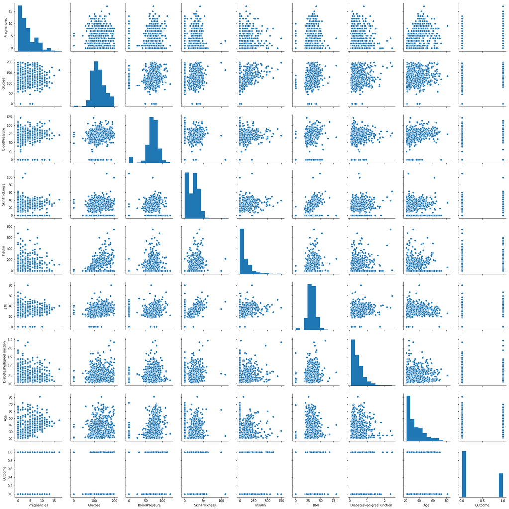

```python
import seaborn as sns
sns.pairplot(full_data)
```

```python
full_data.corr()
```

|  | Pregnancies | Glucose | BloodPressure | SkinThickness | Insulin | BMI | DiabetesPedigreeFunction | Age | Outcome |
| --- | --- | --- | --- | --- | --- | --- | --- | --- | --- |
| Pregnancies | 1.000000 | 0.120405 | 0.149672 | -0.063375 | -0.076600 | 0.019475 | -0.025453 | 0.539457 | 0.224437 |
| Glucose | 0.120405 | 1.000000 | 0.138044 | 0.062368 | 0.320371 | 0.226864 | 0.123243 | 0.254496 | 0.458421 |
| BloodPressure | 0.149672 | 0.138044 | 1.000000 | 0.198800 | 0.087384 | 0.281545 | 0.051331 | 0.238375 | 0.075958 |
| SkinThickness | -0.063375 | 0.062368 | 0.198800 | 1.000000 | 0.448859 | 0.393760 | 0.178299 | -0.111034 | 0.076040 |
| Insulin | -0.076600 | 0.320371 | 0.087384 | 0.448859 | 1.000000 | 0.223012 | 0.192719 | -0.085879 | 0.120924 |
| BMI | 0.019475 | 0.226864 | 0.281545 | 0.393760 | 0.223012 | 1.000000 | 0.125719 | 0.038987 | 0.276726 |
| DiabetesPedigreeFunction | -0.025453 | 0.123243 | 0.051331 | 0.178299 | 0.192719 | 0.125719 | 1.000000 | 0.026569 | 0.155459 |
| Age | 0.539457 | 0.254496 | 0.238375 | -0.111034 | -0.085879 | 0.038987 | 0.026569 | 1.000000 | 0.236509 |
| Outcome | 0.224437 | 0.458421 | 0.075958 | 0.076040 | 0.120924 | 0.276726 | 0.155459 | 0.236509 | 1.000000 |

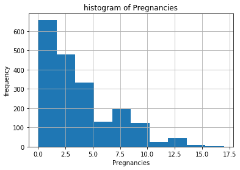

```python
full_data.Pregnancies.hist()
plt.title("histogram of Pregnancies")
plt.xlabel('Pregnancies')
plt.ylabel('frequency')
```

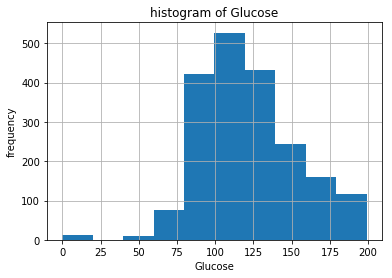

```python
full_data.Glucose.hist()
plt.title("histogram of Glucose")
plt.xlabel('Glucose')
plt.ylabel('frequency')
```

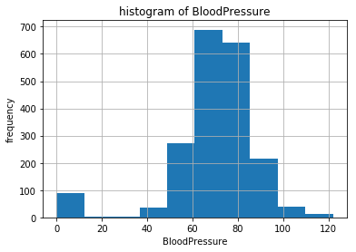

```python
full_data.BloodPressure.hist()
plt.title("histogram of BloodPressure")
plt.xlabel('BloodPressure')
plt.ylabel('frequency')
```

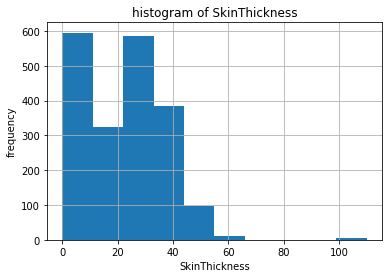

```python
full_data.SkinThickness.hist()
plt.title("histogram of SkinThickness")
plt.xlabel('SkinThickness')
plt.ylabel('frequency')
```

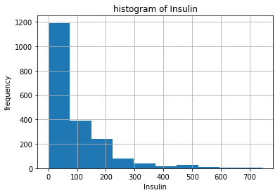

```python
full_data.Insulin.hist()
plt.title("histogram of Insulin")
plt.xlabel('Insulin')
plt.ylabel('frequency')
```

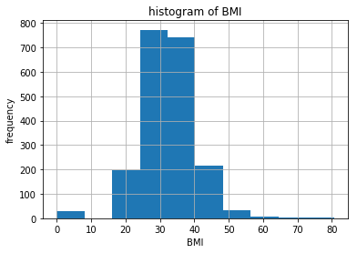

```python
full_data.BMI.hist()
plt.title("histogram of BMI")
plt.xlabel('BMI')
plt.ylabel('frequency')
```

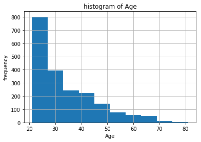

```python
full_data.Age.hist()
plt.title("histogram of Age")
plt.xlabel('Age')
plt.ylabel('frequency')
```

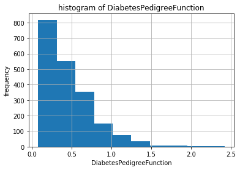

```python
full_data.DiabetesPedigreeFunction.hist()
plt.title("histogram of DiabetesPedigreeFunction")
plt.xlabel('DiabetesPedigreeFunction')
plt.ylabel('frequency')
```

Since we're interested in the outcome of diabetes for each member, we can remove the **outcome** feature from this dataset and store it as its own separate variable `out`. We will use these outcomes as our prediction targets.  
Run the code cell below to remove **outcome** as a feature of the dataset and store it in `out`.

```python
out = full_data['Outcome']
out.head()
```

```
0    1
1    0
2    1
3    1
4    0
Name: Outcome, dtype: int64
```

```python
data = full_data.drop('Outcome',axis = 1)
```

```python
data.head()
```

|  | Pregnancies | Glucose | BloodPressure | SkinThickness | Insulin | BMI | DiabetesPedigreeFunction | Age |
| --- | --- | --- | --- | --- | --- | --- | --- | --- |
| 0 | 2 | 138 | 62 | 35 | 0 | 33.6 | 0.127 | 47 |
| 1 | 0 | 84 | 82 | 31 | 125 | 38.2 | 0.233 | 23 |
| 2 | 0 | 145 | 0 | 0 | 0 | 44.2 | 0.630 | 31 |
| 3 | 0 | 135 | 68 | 42 | 250 | 42.3 | 0.365 | 24 |
| 4 | 1 | 139 | 62 | 41 | 480 | 40.7 | 0.536 | 21 |

```python
data.shape
```

```
(2000, 8)
```

```python
out.value_counts()
```

```
0    1316
1     684
Name: Outcome, dtype: int64
```

```python
from sklearn.preprocessing import StandardScaler
scaler = StandardScaler()
data1 = scaler.fit_transform(data)
data = pd.DataFrame(data1,columns=data.columns)
data.head()
```

|  | Pregnancies | Glucose | BloodPressure | SkinThickness | Insulin | BMI | DiabetesPedigreeFunction | Age |
| --- | --- | --- | --- | --- | --- | --- | --- | --- |
| 0 | -0.515394 | 0.524553 | -0.372481 | 0.873645 | -0.722016 | 0.172683 | -1.063246 | 1.180424 |
| 1 | -1.120495 | -1.159756 | 0.670080 | 0.625186 | 0.402563 | 0.737249 | -0.735551 | -0.856326 |
| 2 | -1.120495 | 0.742890 | -3.604422 | -1.300374 | -0.722016 | 1.473638 | 0.491759 | -0.177409 |
| 3 | -1.120495 | 0.430980 | -0.059713 | 1.308449 | 1.527142 | 1.240448 | -0.327478 | -0.771462 |
| 4 | -0.817945 | 0.555744 | -0.372481 | 1.246334 | 3.596367 | 1.044077 | 0.201161 | -1.026055 |

```python
data.describe()
```

|  | Pregnancies | Glucose | BloodPressure | SkinThickness | Insulin | BMI | DiabetesPedigreeFunction | Age |
| --- | --- | --- | --- | --- | --- | --- | --- | --- |
| count | 2.000000e+03 | 2.000000e+03 | 2.000000e+03 | 2.000000e+03 | 2.000000e+03 | 2.000000e+03 | 2.000000e+03 | 2.000000e+03 |
| mean | -6.927792e-17 | -1.491030e-16 | 1.099676e-16 | 9.869883e-17 | 1.065016e-16 | 2.212952e-16 | 1.243450e-16 | 8.032464e-17 |
| std | 1.000250e+00 | 1.000250e+00 | 1.000250e+00 | 1.000250e+00 | 1.000250e+00 | 1.000250e+00 | 1.000250e+00 | 1.000250e+00 |
| min | -1.120495e+00 | -3.779793e+00 | -3.604422e+00 | -1.300374e+00 | -7.220155e-01 | -3.951097e+00 | -1.214728e+00 | -1.026055e+00 |
| 25% | -8.179445e-01 | -6.918925e-01 | -2.942891e-01 | -1.300374e+00 | -7.220155e-01 | -5.913207e-01 | -7.015452e-01 | -7.714617e-01 |
| 50% | -2.128441e-01 | -1.304560e-01 | 1.487996e-01 | 1.282671e-01 | -3.621503e-01 | 1.313228e-02 | -2.934724e-01 | -3.471387e-01 |
| 75% | 6.948066e-01 | 6.181260e-01 | 5.658243e-01 | 6.873005e-01 | 4.475463e-01 | 5.654243e-01 | 4.732099e-01 | 5.863720e-01 |
| max | 4.022859e+00 | 2.427199e+00 | 2.755204e+00 | 5.532257e+00 | 5.971477e+00 | 5.941067e+00 | 6.025474e+00 | 4.065821e+00 |

## 2. Shuffle and Split Data

- All numerical features have been normalized.
- As always, we will now split the data (both features and their labels) into training and test sets. 80% of the data will be used for training and 20% for testing.
- Set the random_state for train_test_split to a value of your choice. This ensures results are consistent.
- Assign the train and testing splits to X_train, X_test, y_train, and y_test.
- Run the code cell below to perform this split.

```python
from sklearn.model_selection import train_test_split

# TODO: Shuffle and split the data into training and testing subsets
X_train, X_test, y_train, y_test = train_test_split(data,out,test_size = 0.2 ,random_state = 10)

# Success
print("Training and testing split was successful.")
print("Training set has {} samples.".format(X_train.shape[0]))
print("Testing set has {} samples.".format(X_test.shape[0]))
```

```
Training and testing split was successful.
Training set has 1600 samples.
Testing set has 400 samples.
```

# 3.Model Selection

```python
from sklearn.metrics import f1_score
```

```python
from sklearn.linear_model import LogisticRegression

clf_1 = LogisticRegression(random_state=0).fit(X_train, y_train)
pred = clf_1.predict(X_test)
LogisticRegression_score = f1_score(pred,y_test)
f1_score(pred,y_test)
```

```
0.6723404255319149
```

# Fitting a SVM model

```python
from sklearn import svm
clf_3 = svm.SVC(random_state=0).fit(X_train, y_train)
pred = clf_3.predict(X_test)
SVM_score = f1_score(pred,y_test)
f1_score(pred,y_test)
```

```
0.7723577235772358
```

# Fitting a RandomForestClassifier model

```python
from sklearn.ensemble import RandomForestClassifier
clf_6 = RandomForestClassifier(random_state=0).fit(X_train, y_train)
pred = clf_6.predict(X_test)
RandomForest_score = f1_score(pred,y_test)
f1_score(pred,y_test)
```

```
0.944
```

# Fitting a DecisionTreeClassifier model

```python
from sklearn.tree import DecisionTreeClassifier
clf_8 = DecisionTreeClassifier(random_state=0).fit(X_train, y_train)
pred = clf_8.predict(X_test)
DecisionTree_score = f1_score(pred,y_test)
f1_score(pred,y_test)
```

```
0.9328063241106719
```

[figure not shown]

```python
labels = ["SVM", "DecisionTree", "RandomForest"]
usage = [SVM_score, RandomForest_score, DecisionTree_score]

y_positions = range(len(labels))
plt.bar(y_positions,usage)
plt.xticks(y_positions, labels)
plt.ylabel("f1_score(%)")
plt.title("best model selection")
plt.show()
```

# 7. Use grid search to improve this model.

In here, we'll do the following steps:

- First define some parameters to perform grid search on. We suggest to play with max_depth and n_estimators.
- Make a scorer for the model using f1_score.
- Perform grid search on the classifier, using the parameters and the scorer.
- Fit the data to the new classifier.
- Plot the model and find the f1_score.
- If the model is not much better, try changing the ranges for the parameters and fit it again.

```python
# TODO: Import 'GridSearchCV', 'make_scorer', and any other necessary libraries
from matplotlib import pyplot as plt
%matplotlib inline

from sklearn.model_selection import GridSearchCV
from sklearn.metrics import make_scorer, r2_score, fbeta_score
# TODO: Initialize the classifier
clf = RandomForestClassifier(random_state=0)

# TODO: Create the parameters list you wish to tune, using a dictionary if needed.
# HINT: parameters = {'parameter_1': [value1, value2], 'parameter_2': [value1, value2]}
parameters = {'n_estimators': [100, 300, 500],
              'max_depth': [7,9,14]}

# TODO: Make an fbeta_score scoring object using make_scorer()
scorer = make_scorer(f1_score)

# TODO: Perform grid search on the classifier using 'scorer' as the scoring method using GridSearchCV()
grid_obj = GridSearchCV(clf, parameters, scoring=scorer,cv=5)

# TODO: Fit the grid search object to the training data and find the optimal parameters using fit()
grid_fit = grid_obj.fit(X_train, y_train)

# Get the estimator
best_clf = grid_fit.best_estimator_

# Make predictions using the unoptimized and model

best_predictions = best_clf.predict(X_test)
# Report the before-and-afterscores
GridsearchCV_score = f1_score(best_predictions,y_test)
print(f1_score(best_predictions,y_test))
print(best_clf)
```

```
0.9765625
RandomForestClassifier(bootstrap=True, class_weight=None, criterion='gini',
            max_depth=14, max_features='auto', max_leaf_nodes=None,
            min_impurity_decrease=0.0, min_impurity_split=None,
            min_samples_leaf=1, min_samples_split=2,
            min_weight_fraction_leaf=0.0, n_estimators=100, n_jobs=None,
            oob_score=False, random_state=0, verbose=0, warm_start=False)
```

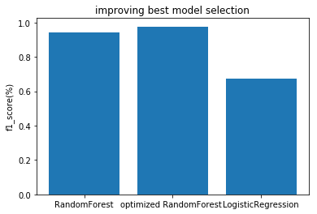

```python
labels = ["RandomForest","optimized RandomForest ", "LogisticRegression" ]
usages = [max(usage),GridsearchCV_score,LogisticRegression_score]

y_positions = range(len(labels))
plt.bar(y_positions,usages)
plt.xticks(y_positions, labels)
plt.ylabel("f1_score(%)")
plt.title("improving best model selection")
plt.show()
```

```python
from sklearn.model_selection import cross_val_score
print(cross_val_score(best_clf, data, out, cv=6,scoring =scorer ))
```

```
[0.99559471 1.         1.         1.         0.94117647 1.        ]
```

# 8. Conclusion

- Note that by using GridSearch we improved the F1 Score from 0.94 to 0.97.